# COMM 3710: Reliability and Validity

# What is Reliability and Validity?

> **Reliability** and **validity** are standards by which we judge success or failure in our measurement of concepts.

**Reliability**

- Reliability is a quality of measurement that refers to consistency. When we assess reliability of a measure, we are asking whether the measure is a consistent indicator of a concept.

**Validity**

- Validity is a quality of measurement that refers to confidence in a measure. A measure that is valid accurately reflects the concept it is intended to measure. The concept of validity also extends to…
  1. precision in study design (**internal validity**, which is important in experiments)
  2. our ability to generalize findings from a sample to a larger population (**external validity**)

Reliability and validity are precision and accuracy, respectively. Using these four terms, describe the dart-thrower in scenarios A, B, and C below. Answers can be found in the video below.

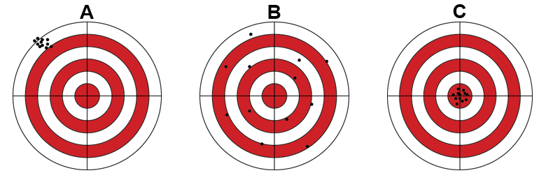

[video not shown]

Back to top

# Types of Reliability

There are four (4) types of reliability:

1. Stability
2. Reproducibility
3. Homogeneity
4. Accuracy

Click on the tabs below to learn more about each type of reliability.

## Stability

Refers to consistency in measures across time. We can evaluate stability using a test-retest method. By measuring a concept at time 1 ($t_1$) and time 2 ($t_2$), we can compare them to see if they are stable across time.

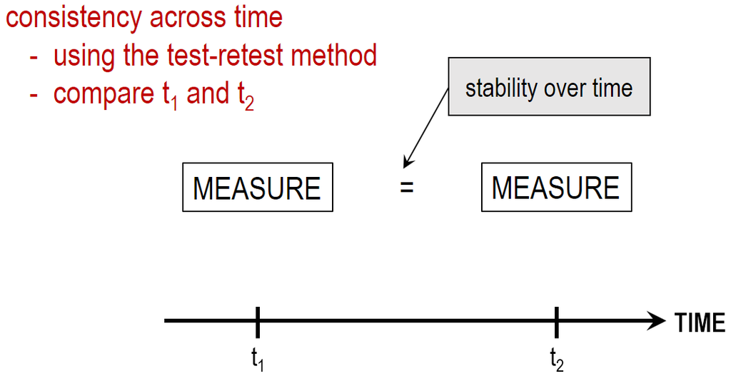

Back to top

## Reproducibility

Refers to consistency between observers. By comparing the results of two different observers who are measuring the same phenomenon using the same measuring device, we can determine whether we have reliability between observers. This reliability between observers is known as **inter-coder reliability**.

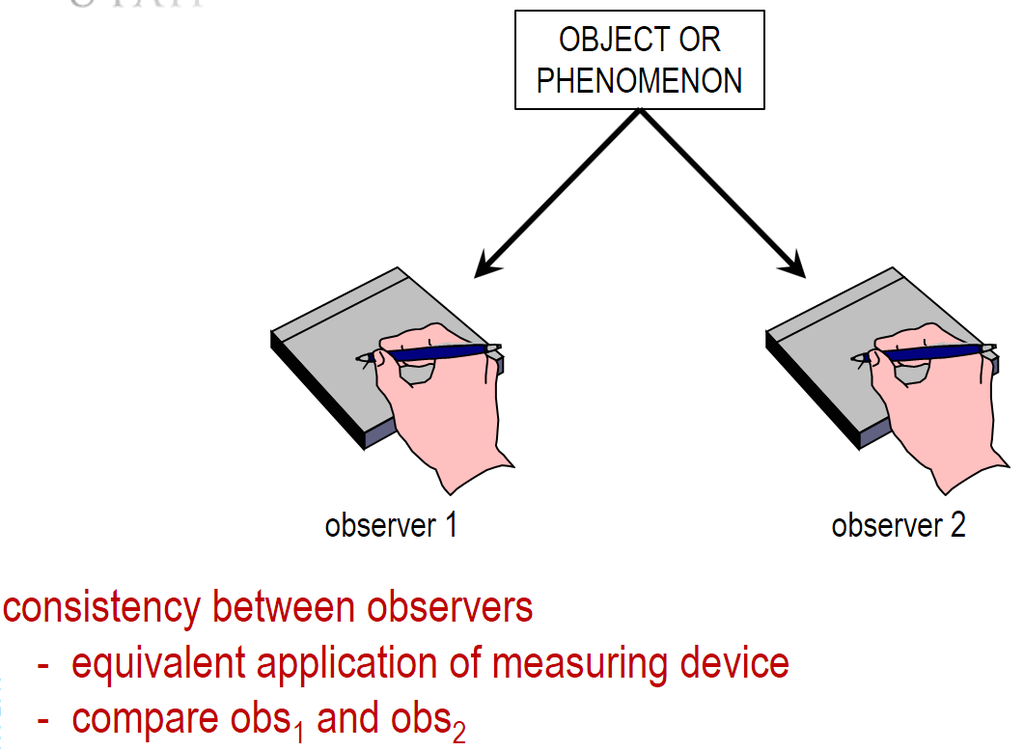

Back to top

## Homogeneity

Refers to consistency between different measures of a single concept. We often use more than one indicator to measure a concept. Homogeneity refers to the reliability of the indicators of a concept. We assess this using **inter-item reliability**. The next section discusses assessing inter-item reliability in more detail.

Back to top

## Accuracy

Refers to the lack of mistakes in measurement. We can increase accuracy of measures by having clear, defined procedures. In addition, observers must have sufficient training, motivation, and concentration.

Back to top

# Assessing Inter-Item Reliability

Inter-item reliability refers to the correlation of each item/indicator with every other item/indicator used in measurement of a particular concept. To begin, let’s first clarify the meaning of a **statistical correlation**.

A **statistical correlation** is a measure of the strength and direction of the relationship between two variables. The three figures below show three different types of relationships (negative, neutral, or positive). See if you can identify the type of relationship in the figure.

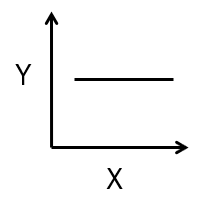

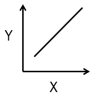

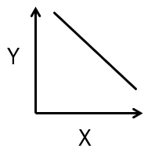

Check your answers with the [Week 4 lecture on relationships](https://yesuncomm.github.io/comm3710/week4.html#Relationships).

To assess inter-item reliability, we use one of three ways. The video below explains each of these.

1. Average inter-item correlation
2. Split-half reliability
3. Cronbach’s alpha ($\alpha$)

[video not shown]

Back to top

# Approaches to Validity

There are three primary approaches or types of validity that we will cover in this course. One can be assessed before data collection, while the remaining two are assessed after data collection.

Before data collection, we can assess:

1. face or content validity

After data collection, we can assess:

2. criterion validity
3. construct validity

Read Chapter 8 of your textbook and make note of the definitions of these terms.

Back to top

# Summary

Here’s a graphical summary of what we have covered on reliability and validity of measures. Remember to post any questions about this week’s content in the Discussion.

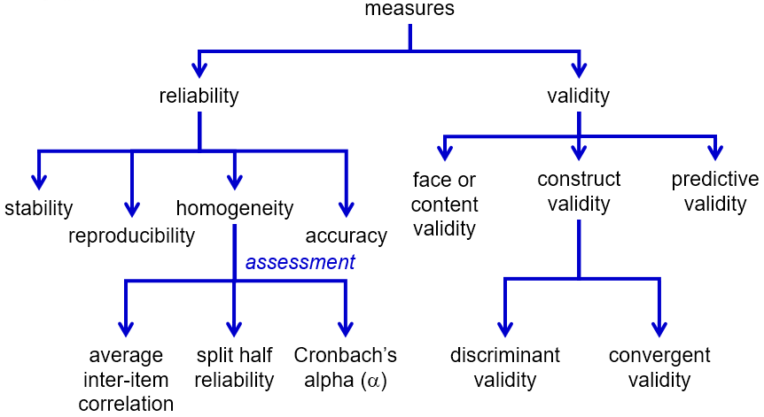

Back to top